# Aula Introdução ao Python Concluida

### **Aula de Introdução - Python em Econometria**

##### Prof Daniel Uhr e Sérgio Daneris

**A presente aula tem como objetivo capacitar os alunos para o entendimento e a utilização da análise de dados através da linguagem de programação Python**

##### *Visual Studio Code*

O Visual Studio Code é um ambiente de desenvolvimento flexível e personalizável. Com suas extensões, suporta Python, uma linguagem popular para análise de dados.

Usando bibliotecas como Pandas e Matplotlib, os desenvolvedores podem realizar análises e visualizações de dados de forma eficiente e poderosa, tornando o processo mais produtivo.

**Extensões:**

- Jupyter Notebook
- Python
- MarkDown
- Github Copilot
- PowerShell
- R

##### *Github - Acesso a pacote de dados.*

GitHub é uma plataforma de desenvolvimento colaborativo que utiliza o sistema de controle de versão Git. A plataforma oferece um ambiente centralizado para que desenvolvedores compartilhem e colaborem em projetos de software. Os repositórios no GitHub são espaços dedicados para armazenar conjuntos de dados e outros arquivos, permitindo que pesquisadores e desenvolvedores compartilhem essas informações de forma acessível ao público. Esses repositórios facilitam o download e o uso desses dados por outros usuários, promovendo a colaboração e a inovação na comunidade.

**Bibliotecas necessárias para análise de dados:**

- Pandas:

Função: Manipulação e análise. Pode ser utilizado para limpeza e preparação, análise exploratória e transformações complexas em conjuntos de dados.

comando: pip install pandas

- Numpy:

Função: Computação numérica eficiente. Pode ser utilizado para operações matemáticas em larga escala, manipulação eficiente de grandes conjuntos de dados numéricos.

comando: pip install numpy

- Matplotib:

Função: Criação de gráficos 2D. Pode ser utilizado para visualização de dados básico, criação de gráficos personalizados para análises específicas.

comando: pip install matplotib

- StatsModels:

Função: Estimativa e interpretação de modelos estatísticos. Pode ser utilizado para modelagem estatística, análise de dados para pesquisas científicas e acadêmicas.

comando: pip install statsmodels

- Linearmodels:

Função: É usada para analisar e estimar modelos estatísticos lineares. Ela facilita a realização de regressões com diferentes configurações, como erros padrão robustos e efeitos fixos/aleatórios.

comandos: pip instal linearmodels

- Seaborn:

Função: Visualização estatística atraente. Pode ser utilizado para exploração visual de relacionamentos em dados complexos, criação de gráficos estatísticos detalhados.

comando: pip install seaborn

- Scipy:

Função: Extensões de funcionalidades numéricas. Pode ser utilizado para análises estatísticas avançadas, modelagem matemática e científica.

comando: pip install scipy

**Prática:**

```python
# Análise de Dados
# 1°) Vamos importar a biblioteca pandas
# 2°) Vamos acessar o banco de dados através de duas maneiras: Baixando direto de um servidor da web (Exemplo: Github) ou através de um diretório do próprio usuário
# 3°) Visualizar as primeiras colunas com print (dados.head)
# 4°) Quando for baixar pelo github colocar (https://raw.githubusercontent.com)

import pandas as pd

url = 'https://raw.githubusercontent.com/sergiodaneris/Wooldridge/main/bwght.csv'

dadosgit= pd.read_csv(url)

print (dadosgit.head)
```

```
<bound method NDFrame.head of       faminc  cigtax    cigprice  bwght  fatheduc  motheduc  parity  male  \
0       13.5    16.5  122.300003    109      12.0      12.0       1     1
1        7.5    16.5  122.300003    133       6.0      12.0       2     1
2        0.5    16.5  122.300003    129       NaN      12.0       2     0
3       15.5    16.5  122.300003    126      12.0      12.0       2     1
4       27.5    16.5  122.300003    134      14.0      12.0       2     1
...      ...     ...         ...    ...       ...       ...     ...   ...
1383    27.5    30.0  138.300003    110      12.0      12.0       4     1
1384     5.5    30.0  138.300003    146       NaN      16.0       2     1
1385    65.0     8.0  118.599998    135      18.0      16.0       2     0
1386    27.5     8.0  118.599998    118       NaN      14.0       2     0
1387    37.5     8.0  118.599998    111      16.0      13.0       2     0

      white  cigs    lbwght  bwghtlbs  packs   lfaminc
0         1     0  4.691348    6.8125    0.0  2.602690
1         0     0  4.890349    8.3125    0.0  2.014903
2         0     0  4.859812    8.0625    0.0 -0.693147
3         0     0  4.836282    7.8750    0.0  2.740840
4         1     0  4.897840    8.3750    0.0  3.314186
...     ...   ...       ...       ...    ...       ...
1383      1     0  4.700480    6.8750    0.0  3.314186
1384      1     0  4.983607    9.1250    0.0  1.704748
1385      1     0  4.905275    8.4375    0.0  4.174387
1386      1     0  4.770685    7.3750    0.0  3.314186
1387      1     0  4.709530    6.9375    0.0  3.624341

[1388 rows x 14 columns]>
```

```python
# Baixar direto de uma pasta do usuário
# Sempre trocar \ por /

dadosusuario = pd.read_csv('C:/Users/sergi/Desktop/Econometria 2/Aulas/bwght.csv')

print (dadosusuario.head)
```

```
<bound method NDFrame.head of       faminc  cigtax    cigprice  bwght  fatheduc  motheduc  parity  male  \
0       13.5    16.5  122.300003    109      12.0      12.0       1     1
1        7.5    16.5  122.300003    133       6.0      12.0       2     1
2        0.5    16.5  122.300003    129       NaN      12.0       2     0
3       15.5    16.5  122.300003    126      12.0      12.0       2     1
4       27.5    16.5  122.300003    134      14.0      12.0       2     1
...      ...     ...         ...    ...       ...       ...     ...   ...
1383    27.5    30.0  138.300003    110      12.0      12.0       4     1
1384     5.5    30.0  138.300003    146       NaN      16.0       2     1
1385    65.0     8.0  118.599998    135      18.0      16.0       2     0
1386    27.5     8.0  118.599998    118       NaN      14.0       2     0
1387    37.5     8.0  118.599998    111      16.0      13.0       2     0

      white  cigs    lbwght  bwghtlbs  packs   lfaminc
0         1     0  4.691348    6.8125    0.0  2.602690
1         0     0  4.890349    8.3125    0.0  2.014903
2         0     0  4.859812    8.0625    0.0 -0.693147
3         0     0  4.836282    7.8750    0.0  2.740840
4         1     0  4.897840    8.3750    0.0  3.314186
...     ...   ...       ...       ...    ...       ...
1383      1     0  4.700480    6.8750    0.0  3.314186
1384      1     0  4.983607    9.1250    0.0  1.704748
1385      1     0  4.905275    8.4375    0.0  4.174387
1386      1     0  4.770685    7.3750    0.0  3.314186
1387      1     0  4.709530    6.9375    0.0  3.624341

[1388 rows x 14 columns]>
```

##### **Vamos análisar cada váriavel do banco de dados**

faminc: Renda familiar.

cigtax: Imposto sobre cigarros.

cigprice: Preço médio do cigarro.

bwght: Peso ao nascer da criança.

fatheduc: Anos de educação do pai.

motheduc: Anos de educação da mãe.

parity: Número de filhos já nascidos (paridade).

male: Gênero do bebê (1 para masculino, 0 para feminino).

white: Indicador de raça branca (1 para branco, 0 para não branco).

cigs: Número de cigarros fumados pela mãe durante a gravidez.

lbwght: Logaritmo natural do peso ao nascer.

bwghtlbs: Peso ao nascer em libras.

packs: Número de maços de cigarro fumados pela mãe durante a gravidez.

lfaminc: Logaritmo natural da renda familiar.

```python
# Criando uma váriavel dentro do dataframe
# Por exemplo uma váriavel  de risco de Baixo Peso ao Nascer
# Essa variável poderia ser criada combinando algumas das variáveis existentes, como o peso da criança ao nascer (bwghtlbs), a educação da mãe (motheduc) e o nível de escolaridade do pai (fatheduc).
# 5.5 é o peso ao nascer considerado baixo para recem nascido
# 12 é o numero minimo de anos de escolaridade

# Criando a variável que indica o risco de BPN
dadosusuario["risco_bnp"] = (dadosusuario["bwghtlbs"] < 5.5) | (dadosusuario["motheduc"] < 12) | (dadosusuario["fatheduc"] < 12)

# Imprimindo a variável
print(dadosusuario["risco_bnp"].head())
```

```
0    False
1     True
2    False
3    False
4    False
Name: risco_bnp, dtype: bool
```

O resultado é uma nova coluna no DataFrame dadosusuario chamada "risco_bnp", onde cada entrada é um valor booleano indicando se o respectivo caso possui ou não risco de baixo peso ao nascer.

```python
# Agora vamos calcular todas as estatisticas descritivas do conjunto de dados
# Média, Mediana, Desvio Padrão do peso ao nascer das crianças

# Exibindo as estatísticas descritivas
print(dadosusuario["bwghtlbs"].describe())
```

```
count    1388.000000
mean        7.418723
std         1.272123
min         1.437500
25%         6.687500
50%         7.500000
75%         8.250000
max        16.937500
Name: bwghtlbs, dtype: float64
```

**Count:** É o número de observações no conjunto de dados.

```python
# Calculando a variância

var = dadosusuario["bwghtlbs"].var()

print(var)
```

```
1.6182963447994607
```

```python
# Agora vamos transformar a variável cigprice em log natural
# lembrando que ja importamos a biblioteca pandas, agora precisamos importar a biblioteca Numpy

import numpy as np

dadosusuario['log_cigprice'] = np.log(dadosusuario['cigprice'])
```

**Quando é necessário transformar a variável e log Natural?**

- Assimetria nos Dados:

Motivação: Quando a distribuição da variável é assimétrica (não é simétrica), a transformação logarítmica pode ajudar a aproximá-la de uma distribuição mais simétrica.

- Redução de Amplitude:

Motivação: Se a variável abrange uma ampla gama de valores, a transformação logarítmica pode reduzir a amplitude dos dados, destacando variações em porcentagens ou proporções em vez de diferenças absolutas.

- Estabilidade de Variância:

Motivação: A transformação logarítmica pode estabilizar a variância, tornando-a mais constante ao longo da escala da variável. Isso é benéfico para modelos estatísticos que assumem homocedasticidade (variância constante).

- Interpretação Multiplicativa:

Motivação: Em alguns contextos, as diferenças percentuais são mais relevantes do que as diferenças absolutas. A transformação logarítmica converte as diferenças absolutas em diferenças percentuais, facilitando a interpretação multiplicativa.

- Linearização de Relacionamentos Não Lineares:

Motivação: Quando há um relacionamento exponencial ou logarítmico entre variáveis, a transformação logarítmica pode linearizar esses relacionamentos, tornando-os mais adequados para modelagem linear.

- Observações Importantes:

A transformação logarítmica é mais apropriada quando a variável contém apenas valores positivos.

A interpretação dos resultados após a transformação deve levar em consideração a escala logarítmica.

A escolha de transformar variáveis depende do contexto específico dos dados e dos objetivos da análise.

> Podemos observar que foi criada uma coluna log_cigprice dentro do dataframe dadosusuario.

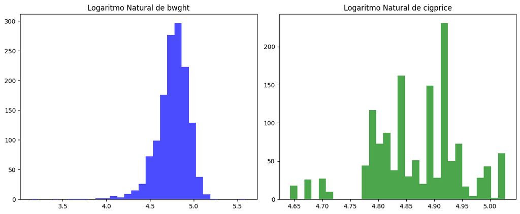

```python
# Agora vamos plotar a distribuição logaritmica (lbwght e log_cigprice) e logo em seguida criar um grafico que represente essa distribuição
# Para realizar esse exercicio precisamos importar a biblioteca Matplotib

import matplotlib.pyplot as plt

# Plotar distribuição logarítmica
plt.figure(figsize=(12, 5))

plt.subplot(1, 2, 1)
plt.hist(dadosusuario['lbwght'], bins=30, color='blue', alpha=0.7)
plt.title('Logaritmo Natural de bwght')

plt.subplot(1, 2, 2)
plt.hist(dadosusuario['log_cigprice'], bins=30, color='green', alpha=0.7)
plt.title('Logaritmo Natural de cigprice')

plt.tight_layout()
plt.show()
```

```python
# Agora vamos transformar as variáveis bwght e cigprice em exponencial e também colocar ao quadradro
# Exponencial
dadosusuario['exp_bwght'] = np.exp(dadosusuario['bwght'])
dadosusuario['exp_cigprice'] = np.exp(dadosusuario['cigprice'])

# Ao quadrado
dadosusuario['bwght_squared'] = dadosusuario['bwght'] ** 2
dadosusuario['cigprice_squared'] = dadosusuario['cigprice'] ** 2
```

- Transformação Exponencial:

Motivação: Estabilização de variância, linearização de relacionamentos exponenciais, interpretação multiplicativa.

- Elevação ao Quadrado:

Motivação: Realce de diferenças extremas, captura de não linearidades, redução de assimetria, ajuste de modelos polinomiais. Podemos observar que foi criada outras quatro colunas no banco de dados.

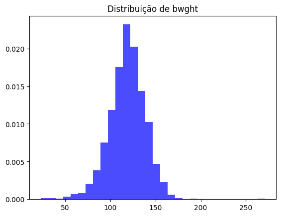

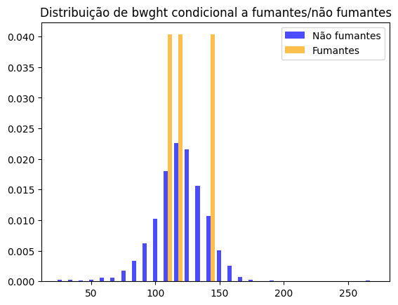

```python
# Vamos plotar a distribuição de variável (bwght)
# E iremos realizar a distribuição condicional (bwght para fumantes e não fumantes)


# Plotar distribuição
plt.hist(dadosusuario['bwght'], bins=30, color='blue', alpha=0.7, density=True)
plt.title('Distribuição de bwght')
plt.show()

# Distribuição condicional
plt.figure()
plt.hist([dadosusuario[dadosusuario['cigs'] == 0]['bwght'], dadosusuario[dadosusuario['cigs'] == 1]['bwght']],
         bins=30, color=['blue', 'orange'], alpha=0.7, label=['Não fumantes', 'Fumantes'], density=True)
plt.title('Distribuição de bwght condicional a fumantes/não fumantes')
plt.legend()
plt.show()
```

Este histograma condicional compara a distribuição de bwght (peso ao nascer) dos bebes entre fumantes e não fumantes. Pode indicar se há diferenças notáveis nas distribuições.

```python
# Criando a variável de média condicional
# De bwght ao fumantes e não fumantes
# A partir do momento que rodarmos, ira criar uma coluna a mais no banco de dados

dadosusuario['mean_cond_bwght'] = dadosusuario.groupby('cigs')['bwght'].transform('mean')
```

```python
# Diferença de médias de duas variáveis: Teste T
# Usar a biblioteca Scipy

from scipy.stats import ttest_ind

result = ttest_ind(dadosusuario['bwght'], dadosusuario['cigs'], nan_policy='omit')
print(result)
```

```
TtestResult(statistic=204.81133841840696, pvalue=0.0, df=2774.0)
```

Teste T: É o valor numérico que representa a diferença entre as médias das duas amostras, normalizado pelo erro padrão dessa diferença. Em termos simples, indica o quão longe as médias estão uma da outra em relação à variabilidade dos dados. Nesse caso o valor foi de 204.81133841840696

P Valor: A probabilidade de observar uma estatística t (ou uma mais extrema) sob a hipótese nula. Em outras palavras, o valor p informa quão provável é que a diferença observada seja devida ao acaso. Nesse caso o valor foi 0.0

Degrees of Freedom (Graus de Liberdade): O número de graus de liberdade associado ao teste t. Em um teste t de duas amostras, os graus de liberdade são determinados pelo tamanho das amostras. Nesse caso o valor foi 2774.0

Em resumo:

A estatística t é grande (204.81), indicando uma diferença substancial entre as médias. O valor p é muito próximo de zero (0.0), sugerindo que essa diferença é estatisticamente significativa. Os graus de liberdade são 2774.

Nesse caso, pode-ee concluir que há uma diferença estatisticamente significativa entre as médias das duas amostras.

```python
# Gerando tabelas de estatistica descritivas:

desc_stats = dadosusuario.groupby('cigs')['bwght'].describe()
print(desc_stats)
```

```
       count        mean        std    min     25%    50%     75%    max
cigs
0     1176.0  120.061224  20.268487   23.0  108.00  121.0  133.00  271.0
1        3.0  122.666667  15.885003  113.0  113.50  114.0  127.50  141.0
2        4.0  109.500000  20.024984   97.0   97.00  101.0  113.50  139.0
3        7.0  115.571429  18.173764   89.0  105.00  115.0  128.00  139.0
4        9.0  109.888889  17.877671   83.0  101.00  108.0  120.00  143.0
5       19.0  114.000000  16.093477   87.0  102.00  119.0  123.50  141.0
6        6.0  123.166667  22.112591   91.0  110.50  125.0  135.75  153.0
7        4.0  120.000000  16.083117  100.0  110.50  123.0  132.50  134.0
8        5.0   91.000000  24.392622   50.0   92.00   96.0  103.00  114.0
9        1.0  128.000000        NaN  128.0  128.00  128.0  128.00  128.0
10      55.0  112.563636  19.911623   68.0  100.00  113.0  122.50  159.0
12       5.0  106.800000  15.706686   90.0   98.00  103.0  112.00  131.0
15      19.0  108.052632  16.614832   71.0  102.50  111.0  117.50  131.0
20      62.0  110.032258  20.095646   60.0   99.00  112.5  123.25  151.0
30       5.0  108.200000  19.266551   91.0   94.00  102.0  116.00  138.0
40       6.0  106.500000  21.210846   81.0   90.75  105.5  120.25  136.0
46       1.0  121.000000        NaN  121.0  121.00  121.0  121.00  121.0
50       1.0   90.000000        NaN   90.0   90.00   90.0   90.00   90.0
```

```python
# Regressão linear: Rodar regressão sem covariáveis (peso bebê x fumante):
# Para rodar a regressão iremos usar a biblioteca Statsmodels

import statsmodels.api as sm

# Adicionando uma constante para o modelo
X = sm.add_constant(dadosusuario['cigs'])
y = dadosusuario['bwght']

# Ajustar o modelo
model = sm.OLS(y, X).fit()

# Imprimir os resultados
print(model.summary())
```

```
                            OLS Regression Results
==============================================================================
Dep. Variable:                  bwght   R-squared:                       0.023
Model:                            OLS   Adj. R-squared:                  0.022
Method:                 Least Squares   F-statistic:                     32.24
Date:                Tue, 14 Nov 2023   Prob (F-statistic):           1.66e-08
Time:                        13:36:28   Log-Likelihood:                -6135.5
No. Observations:                1388   AIC:                         1.227e+04
Df Residuals:                    1386   BIC:                         1.229e+04
Df Model:                           1
Covariance Type:            nonrobust
==============================================================================
                 coef    std err          t      P>|t|      [0.025      0.975]
------------------------------------------------------------------------------
const        119.7719      0.572    209.267      0.000     118.649     120.895
cigs          -0.5138      0.090     -5.678      0.000      -0.691      -0.336
==============================================================================
Omnibus:                      118.187   Durbin-Watson:                   1.924
Prob(Omnibus):                  0.000   Jarque-Bera (JB):              635.742
Skew:                          -0.156   Prob(JB):                    8.92e-139
Kurtosis:                       6.301   Cond. No.                         6.72
==============================================================================

Notes:
[1] Standard Errors assume that the covariance matrix of the errors is correctly specified.
```

O coeficiente para cigs indica a mudança média em bwght associada a um aumento de uma unidade em cigs.

```python
# Iremos rodar uma regressão adicionando outras variáveis

# Supondo que 'male' e 'packs' sejam as covariáveis
X = sm.add_constant(dadosusuario[['cigs', 'male', 'packs']])
model = sm.OLS(y, X).fit()

# Imprimir os resultados
print(model.summary())
```

```
                            OLS Regression Results
==============================================================================
Dep. Variable:                  bwght   R-squared:                       0.030
Model:                            OLS   Adj. R-squared:                  0.028
Method:                 Least Squares   F-statistic:                     14.18
Date:                Tue, 14 Nov 2023   Prob (F-statistic):           4.21e-09
Time:                        13:39:56   Log-Likelihood:                -6130.4
No. Observations:                1388   AIC:                         1.227e+04
Df Residuals:                    1384   BIC:                         1.229e+04
Df Model:                           3
Covariance Type:            nonrobust
==============================================================================
                 coef    std err          t      P>|t|      [0.025      0.975]
------------------------------------------------------------------------------
const        118.3511      0.804    147.266      0.000     116.775     119.928
cigs        2.002e+07   1.22e+07      1.635      0.102      -4e+06     4.4e+07
male           2.8640      1.079      2.653      0.008       0.747       4.981
packs      -4.004e+08   2.45e+08     -1.635      0.102   -8.81e+08       8e+07
==============================================================================
Omnibus:                      123.384   Durbin-Watson:                   1.926
Prob(Omnibus):                  0.000   Jarque-Bera (JB):              701.964
Skew:                          -0.155   Prob(JB):                    3.72e-153
Kurtosis:                       6.470   Cond. No.                     2.89e+09
==============================================================================

Notes:
[1] Standard Errors assume that the covariance matrix of the errors is correctly specified.
[2] The smallest eigenvalue is 6.7e-15. This might indicate that there are
strong multicollinearity problems or that the design matrix is singular.
```

**Explicando a Regressão:**

- R-squared e Adj. R-squared:

Interpretação: A porcentagem de variabilidade em bwght explicada pelo modelo é baixa (R-squared = 0.03), indicando que o modelo não captura a maior parte da variação na variável dependente.

- F-statistic e Prob (F-statistic):

Interpretação: O teste F global sugere que pelo menos uma das variáveis independentes é estatisticamente significativa para explicar a variabilidade em bwght, com um p-valor baixo (Prob (F-statistic) < 0.05).

- Coeficientes e P>|t|:

Interpretação: A variável male é estatisticamente significativa (p < 0.05), indicando uma associação significativa com bwght. As variáveis cigs e packs não são estatisticamente significativas.

- Estatísticas sobre os resíduos:

- Cond. No.:

Interpretação: A alta condição número sugere possível multicolinearidade entre as variáveis independentes.

- Notas:

Interpretação: O modelo assume que a matriz de covariância dos erros está corretamente especificada. Além disso, pode haver problemas de multicolinearidade.

Em resumo, o modelo apresenta algumas limitações, incluindo baixo poder de explicação (baixo R-squared), falta de normalidade nos resíduos e possíveis problemas de multicolinearidade. A variável male é a única que mostra uma associação estatisticamente significativa com bwght neste modelo. Recomenda-se uma análise mais aprofundada e consideração de outras variáveis relevantes.

```python
# Criando uma Tabela com os resultados da ultima regressão.

results_table = pd.DataFrame({
    'Variable': ['Intercept'] + list(X.columns[1:]),
    'Coefficient': model.params.values,
    'Std. Error': model.bse.values,
    't-value': model.tvalues.values,
    'p-value': model.pvalues.values
})

print(results_table)
```

```
    Variable   Coefficient    Std. Error     t-value   p-value
0  Intercept  1.183511e+02  8.036556e-01  147.265986  0.000000
1       cigs  2.001904e+07  1.224343e+07    1.635084  0.102259
2       male  2.863965e+00  1.079341e+00    2.653440  0.008059
3      packs -4.003809e+08  2.448686e+08   -1.635084  0.102259
```

A tabela resume os coeficientes, erros padrão, estatísticas t e valores p para cada variável no modelo. Ajuda a avaliar a significância estatística das relações entre as variáveis.